# Corpus Masterclass 1

Mark Alfano

27 April 2025

# Set working directory

```r
setwd("~/Documents/Philosophy/Experimental/R")
```

# load required packages

```r
require(readtext)
require(quanteda)
require(quanteda.textplots)
require(quanteda.corpora)
require(quanteda.textstats)
require(topicmodels)
require(dplyr)
require(tidyr)
require(tidytext)
require(ggplot2)
require(network)
require(igraph)
require(gridExtra)
library(lexicon)
library(reshape2)
library(stringi)
```

# Full corpus exploration

## Have a look at the SOTU corpora

```r
head(data_corpus_sotu)
```

```
## Corpus consisting of 6 documents and 6 docvars.
## Washington-1790 :
## "Fellow-Citizens of the Senate and House of Representatives: ..."
##
## Washington-1790b :
## "Fellow-Citizens of the Senate and House of Representatives: ..."
##
## Washington-1791 :
## "Fellow-Citizens of the Senate and House of Representatives: ..."
##
## Washington-1792 :
## "Fellow-Citizens of the Senate and House of Representatives: ..."
##
## Washington-1793 :
## "Fellow-Citizens of the Senate and House of Representatives: ..."
##
## Washington-1794 :
## "Fellow-Citizens of the Senate and House of Representatives: ..."
```

```r
tail(data_corpus_sotu)
```

```
## Corpus consisting of 6 documents and 6 docvars.
## Obama-2015 :
## "Mr. Speaker, Mr. Vice President, Members of Congress, my fel..."
##
## Obama-2016 :
## "Thank you. Mr. Speaker, Mr. Vice President, Members of Congr..."
##
## Trump-2017 :
## "Thank you very much. Mr. Speaker, Mr. Vice President, member..."
##
## Trump-2018 :
## "Mr. Speaker, Mr. Vice President, Members of Congress, the Fi..."
##
## Trump-2019 :
## "Madam Speaker, Mr. Vice President, Members of Congress, the ..."
##
## Trump-2020 :
## "Madam Speaker, Mr. Vice President, Members of Congress, the ..."
```

## Have a look at a couple of Washington’s speeches

```r
as.character(data_corpus_sotu)[1]
```

```
##                                                                                                                                                                                                                                                                                                          …
## "Fellow-Citizens of the Senate and House of Representatives:\n\nI embrace with great satisfaction the opportunity which now presents itself of congratulating you on the present favorable prospects of our public affairs. The recent accession of the important state of North Carolina to the Constitu…
```

```r
as.character(data_corpus_sotu)[2]
```

```
##                                                                                                                                                                                                                                                                                                          …
## "Fellow-Citizens of the Senate and House of Representatives:\n\nIn meeting you again I feel much satisfaction in being able to repeat my congratulations on the favorable prospects which continue to distinguish our public affairs. The abundant fruits of another year have blessed our country with p…
```

## Summarize the corpus

```r
summary(data_corpus_sotu)
```

```
## Corpus consisting of 241 documents, showing 100 documents:
##
##              Text Types Tokens Sentences     FirstName  President       Date
##   Washington-1790   460   1167        24        George Washington 1790-01-08
##  Washington-1790b   591   1501        38        George Washington 1790-12-08
##   Washington-1791   814   2471        58        George Washington 1791-10-25
##   Washington-1792   769   2282        59        George Washington 1792-11-06
##   Washington-1793   800   2116        54        George Washington 1793-12-03
##   Washington-1794  1134   3192        77        George Washington 1794-11-19
##   Washington-1795   819   2149        51        George Washington 1795-12-08
##   Washington-1796  1003   3090        78        George Washington 1796-12-07
##        Adams-1797   731   2230        59          John      Adams 1797-11-22
##        Adams-1798   833   2368        58          John      Adams 1798-12-08
##        Adams-1799   597   1624        36          John      Adams 1799-12-03
##        Adams-1800   562   1489        40          John      Adams 1800-11-22
##    Jefferson-1801  1098   3493        90        Thomas  Jefferson 1801-12-08
##    Jefferson-1802   821   2392        60        Thomas  Jefferson 1802-12-15
##    Jefferson-1803   835   2460        46        Thomas  Jefferson 1803-10-17
##    Jefferson-1804   743   2281        48        Thomas  Jefferson 1804-11-08
##    Jefferson-1805   982   3168        76        Thomas  Jefferson 1805-12-03
##    Jefferson-1806   966   3108        74        Thomas  Jefferson 1806-12-02
##    Jefferson-1807   856   2603        60        Thomas  Jefferson 1807-10-27
##    Jefferson-1808   954   2916        70        Thomas  Jefferson 1808-11-08
##      Madison-1809   699   1950        40         James    Madison 1809-11-29
##      Madison-1810   893   2615        61         James    Madison 1810-12-05
##      Madison-1811   829   2439        46         James    Madison 1811-11-05
##      Madison-1812  1126   3493        87         James    Madison 1812-11-04
##      Madison-1813  1074   3521        69         James    Madison 1813-12-07
##      Madison-1814   831   2282        50         James    Madison 1814-09-20
##      Madison-1815  1050   3387        59         James    Madison 1815-12-05
##      Madison-1816  1086   3614        72         James    Madison 1816-12-03
##       Monroe-1817  1221   4812       123         James     Monroe 1817-12-12
##       Monroe-1818  1243   4726       118         James     Monroe 1818-11-16
##       Monroe-1819  1196   5091       132         James     Monroe 1819-12-07
##       Monroe-1820  1319   6323       158         James     Monroe 1820-11-14
##       Monroe-1821  1319   6323       158         James     Monroe 1821-12-03
##       Monroe-1822  1265   5145       118         James     Monroe 1822-12-03
##       Monroe-1823  1593   6924       187         James     Monroe 1823-12-02
##       Monroe-1824  1753   9167       248         James     Monroe 1824-12-07
##        Adams-1825  2151   9773       212   John Quincy      Adams 1825-12-06
```

[output cut: 149 more lines]

```
##   written SOTU            Republican
##   written SOTU            Republican
##   written SOTU            Republican
##   written SOTU            Republican
##   written SOTU            Republican
##   written SOTU            Republican
##   written SOTU            Republican
##   written SOTU            Republican
##   written SOTU            Republican
##   written SOTU            Republican
##   written SOTU            Republican
##   written SOTU            Democratic
##   written SOTU            Democratic
##   written SOTU            Democratic
##   written SOTU            Democratic
```

This is a slightly annoying format because the Date column includes not just the year but also the month and day. Let’s split that column into three so that we can plot some yearly comparisons. We also have to coerce the new Year column to be numeric because otherwise R thinks it’s a string variable.

### Clean up corpus

```r
tokenInfo <- summary(data_corpus_sotu)

tokenInfo <- separate(tokenInfo,
                      Date,
                      c('Year', 'Month', 'Day')
                      )

tokenInfo$Year <- as.numeric(tokenInfo$Year) #because separate makes Year a string rather than a number
```

## visualize word count, comparing different parties

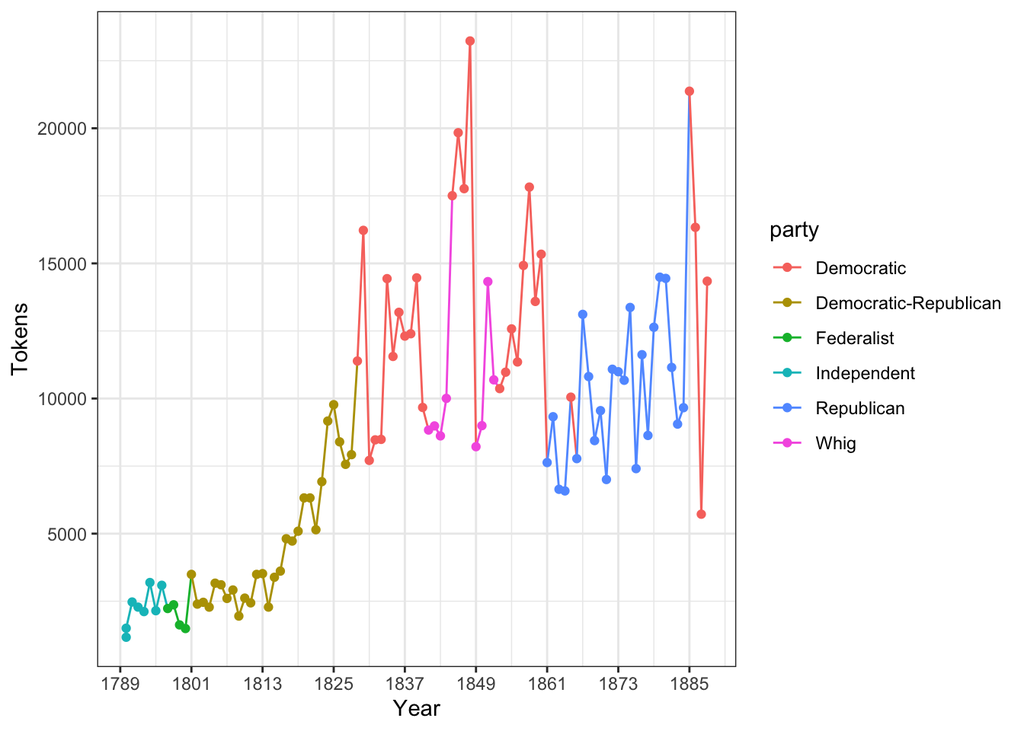

```r
ggplot(data=tokenInfo,
       aes(x = Year,
           y = Tokens,
           group = 1,
           color = party)
       ) +
      geom_line() + #should it be a line though?
      geom_point() + # maybe a histogram would be more informative?
      scale_x_continuous(labels = c(seq(1789, 2017, 12)), breaks = seq(1789, 2017, 12)) + #note that we don't go all the way to 2017. Why?
      theme_bw()
```

## Convert the corpus into a document feature matrix (dfmat), removing punctuation and English stopwords; trim dfmat by excluding rare words

```r
toks_sotu <- tokens(data_corpus_sotu,
                    remove_punct = TRUE) # what happens when we keep the punctuation?

dfmat_sotu <- dfm(toks_sotu) # wtf is a dfmat (document feature matrix?)

dfmat_sotu <- dfm_remove(dfmat_sotu,
                         pattern = stopwords("en")) # why remove stopwords? What counts as a stopword? Who gets to say what counts as a stopword?

dfmat_sotu <- dfm_trim(dfmat_sotu,
                       min_termfreq = 5, # why 5?
                       min_docfreq = 3) #why 3?

head(dfmat_sotu)
```

```
## Document-feature matrix of: 6 documents, 11,931 features (94.72% sparse) and 6 docvars.
##                   features
## docs               fellow-citizens senate house representatives embrace great
##   Washington-1790                1      2     3               3       1     4
##   Washington-1790b               1      2     3               3       0     4
##   Washington-1791                1      3     3               3       0     0
##   Washington-1792                1      2     3               3       0     0
##   Washington-1793                1      2     3               3       0     0
##   Washington-1794                1      2     4               3       0     1
##                   features
## docs               satisfaction opportunity now presents
##   Washington-1790             2           1   1        1
##   Washington-1790b            1           0   2        0
##   Washington-1791             3           1   0        0
##   Washington-1792             3           0   2        0
##   Washington-1793             0           1   2        0
##   Washington-1794             0           1   3        0
## [ reached max_nfeat ... 11,921 more features ]
```

## Generate top features

```r
topfeatures(dfmat_sotu,
            20) # why 20?
```

```
## government     states   congress     united        can       year     people
##       7444       6942       5797       5181       4845       4617       4288
##       upon          $    country       must        may        new        now
##       4229       4191       3623       3602       3595       3574       3538
##      great       made     public       time       last        one
##       3469       3468       3400       3115       3036       3010
```

## Generate a word cloud

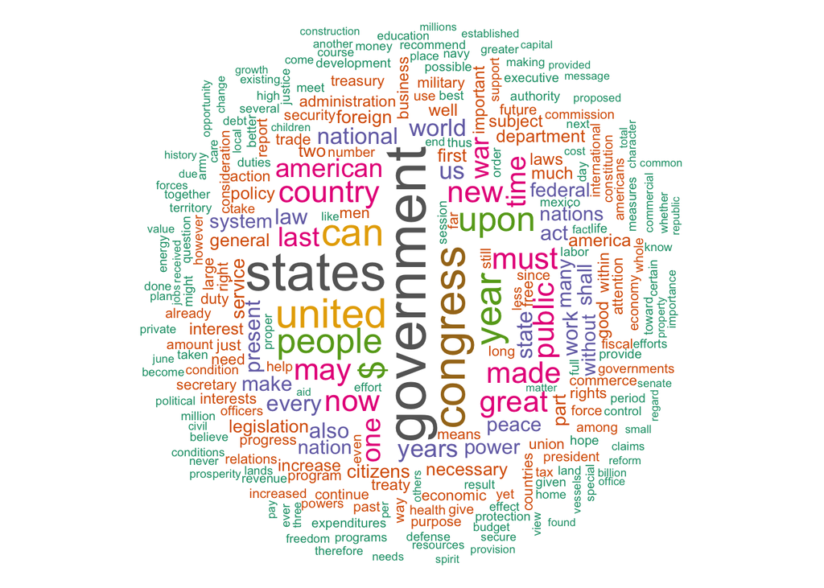

```r
set.seed(1000)
textplot_wordcloud(dfmat_sotu,
                   min_count = 600, # why 600?
                   random_order = FALSE, # why false?
                   rotation = .25, # other rotations?
                   color = RColorBrewer::brewer.pal(8, "Dark2") # what is color brewer? (https://colorbrewer2.org/#type=sequential&scheme=BuGn&n=3)
                   )
```

## Use Latent Dirichlet Allocation to build topic models:

```r
set.seed(100)
if (require(topicmodels)) {
    my_lda_fit <- LDA(convert(dfmat_sotu,
                              to = "topicmodels"),
                      k = 8) # is 8 appropriate?

    get_terms(my_lda_fit,
              10) # why 10?
}
```

```
##       Topic 1     Topic 2   Topic 3      Topic 4      Topic 5
##  [1,] "people"    "world"   "$"          "government" "year"
##  [2,] "america"   "must"    "government" "can"        "federal"
##  [3,] "can"       "war"     "states"     "upon"       "congress"
##  [4,] "new"       "can"     "upon"       "law"        "new"
##  [5,] "must"      "people"  "year"       "great"      "program"
##  [6,] "us"        "peace"   "people"     "public"     "government"
##  [7,] "american"  "nations" "united"     "country"    "economic"
##  [8,] "now"       "us"      "made"       "people"     "programs"
##  [9,] "years"     "free"    "time"       "made"       "administration"
## [10,] "americans" "great"   "last"       "congress"   "also"
##       Topic 6      Topic 7      Topic 8
##  [1,] "government" "government" "states"
##  [2,] "states"     "states"     "united"
##  [3,] "public"     "united"     "congress"
##  [4,] "upon"       "congress"   "may"
##  [5,] "may"        "$"          "war"
##  [6,] "country"    "upon"       "government"
##  [7,] "can"        "year"       "last"
##  [8,] "made"       "made"       "$"
##  [9,] "congress"   "may"        "great"
## [10,] "united"     "now"        "year"
```

# Further comparative exploration by speech

## Top features by speech

```r
topfeatures(dfmat_sotu,
            10, #why 10?
            decreasing = TRUE, #why decreasing?
            groups = docnames(dfmat_sotu)
            )
```

```
## $`Adams-1797`
##        united        states        treaty           may      citizens
##            18            18             9             8             8
## commissioners        within      commerce           can      measures
##             8             7             7             6             6
##
## $`Adams-1798`
##     states     united     france        can   commerce   measures       part
##         15         14         10          8          8          7          7
##      great    country government
##          6          6          6
##
## $`Adams-1799`
##       united       states   government    gentlemen      country    necessary
##           10           10            8            7            6            5
##        great satisfactory       people         made
##            4            4            4            4
##
## $`Adams-1800`
##        may  gentlemen      great     public     united     states   congress
##          9          8          7          7          7          7          6
##    country protection   commerce
##          5          5          5
##
## $`Adams-1825`
##        upon    congress         may      states           $        last
##          44          36          35          30          28          25
##      united      public improvement       first
##          24          23          22          21
##
## $`Adams-1826`
##        $   states   united     upon congress     last     year      act
##       52       48       46       40       36       32       27       24
##      may  present
##       23       21
##
## $`Adams-1827`
##       upon     states     united   congress          $        may     public
##         37         33         30         27         27         21         19
## government        act       year
```

[output cut: 1350 more lines]

```
## $`Wilson-1918`
##     men     war    upon   great country     may   every     can     now   shall
##      27      24      21      20      16      16      16      15      14      14
##
## $`Wilson-1919`
##       must      labor        can   congress government       upon    country
##         24         18         17         17         16         16         15
## conditions        war      world
##         15         14         14
##
## $`Wilson-1920`
##       upon government      faith   congress        war  democracy      world
##         19         17         16         14         11         11         10
##          $    present     united
##          9          8          8
```

## Hierarchical clustering of speeches

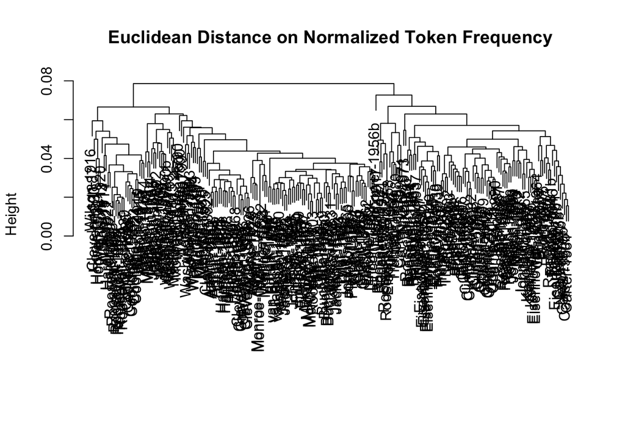

```r
tstat_dist <- textstat_dist(dfm_weight(dfmat_sotu,
                                       scheme = "prop") # could instead use count, propmax, logcount, etc.
                            )

sotu_cluster <- hclust(as.dist(tstat_dist))

sotu_cluster$labels <- docnames(dfmat_sotu)

plot(sotu_cluster,
     xlab = "",
     sub = "",
     main = "Euclidean Distance on Normalized Token Frequency")
```

That’s a bit busy. Let’s replot but only from 1980 to the present. This example uses tidyverse rather than base R, but accomplishes the same thing.

### Hierarchical clustering of speeches from 1980 to the present

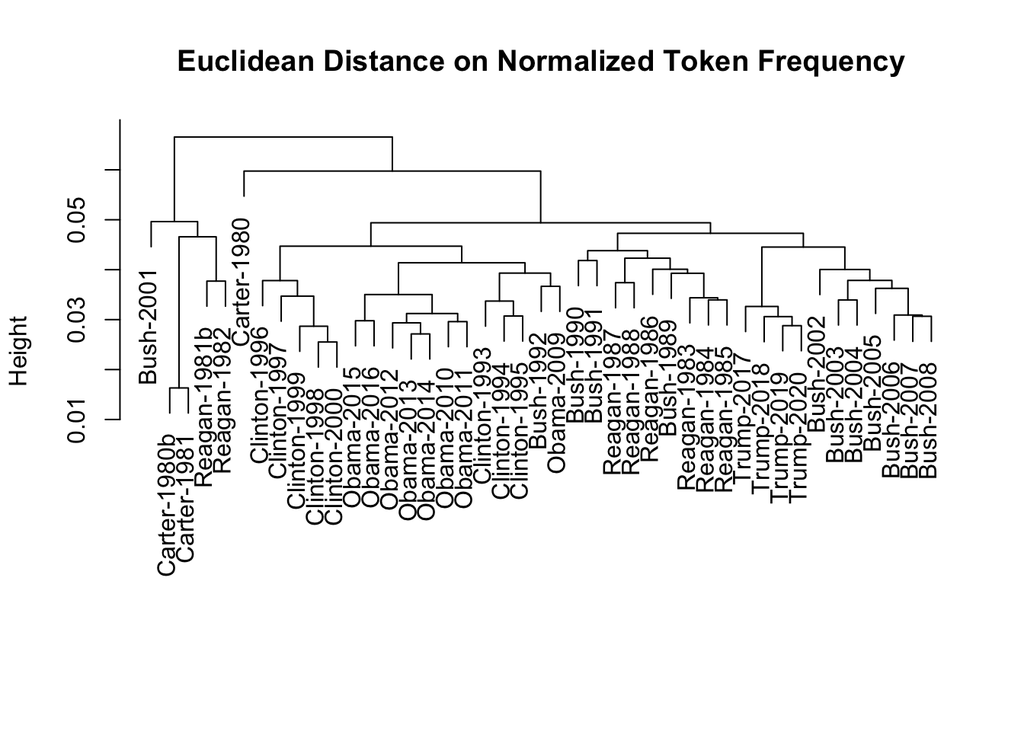

```r
pres_dfm <- tokens(corpus_subset(data_corpus_sotu,
                                 Date > "1980-01-01"), # how did we arrive at this date?
                                  remove_punct = TRUE) %>%
  tokens_wordstem("en") %>%
  tokens_remove(stopwords("en")) %>%
  dfm() %>%
  dfm_trim(min_termfreq = 5, # why 5?
           min_docfreq = 3) # why 3?

# hierarchical clustering - get distances on normalized dfm
pres_dist_mat <- dfm_weight(pres_dfm,
                            scheme = "prop") %>%
    textstat_dist(method = "euclidean") %>%
    as.dist()

# hiarchical clustering the distance object
pres_cluster <- hclust(pres_dist_mat)

# label with document names
pres_cluster$labels <- docnames(pres_dfm)

# plot as a dendrogram
plot(pres_cluster, xlab = "", sub = "",
     main = "Euclidean Distance on Normalized Token Frequency")
```

A lot of people prefer cosine distance to Euclidean. We can accommodate that by using textstat_simil and specifying cosine as the method.

### Hierarchical clustering using cosine distance

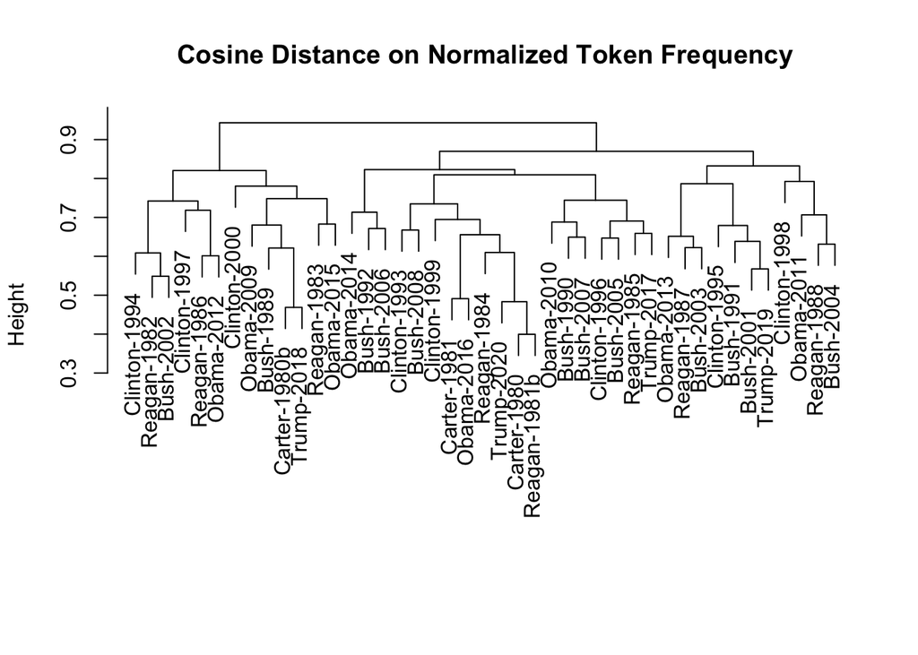

```r
pres_dfm <- tokens(corpus_subset(data_corpus_sotu,
                                 Date > "1980-01-01"),
                                  remove_punct = TRUE) %>%
  tokens_wordstem("en") %>%
  tokens_remove(stopwords("en")) %>%
  dfm() %>%
  dfm_trim(min_termfreq = 5,
           min_docfreq = 3)

# hierarchical clustering - get distances on normalized dfm
pres_dist_mat <- dfm_weight(pres_dfm,
                            scheme = "prop") %>%
    textstat_simil(method = "cosine") %>% # what other methods can we use? Why?
    as.dist()

# hierchical clustering the distance object
pres_cluster <- hclust(pres_dist_mat)

# label with document names
pres_cluster$labels <- docnames(pres_dfm)

# plot as a dendrogram
plot(pres_cluster, xlab = "", sub = "",
     main = "Cosine Distance on Normalized Token Frequency")
```

We can also plot the early SOTU speeches by fiddling with the Date parameter.

### Hierarchical of early SOTU speeches using euclidean

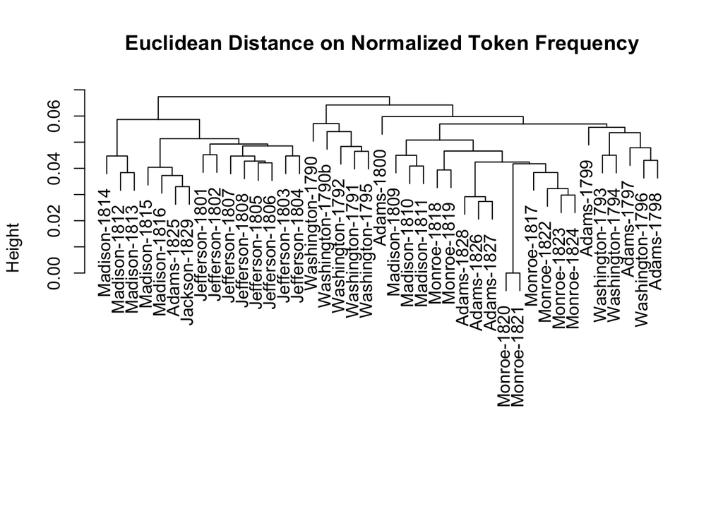

```r
pres_dfm <- tokens(corpus_subset(data_corpus_sotu,
                                 Date < "1830-01-01"),
                                  remove_punct = TRUE) %>%
  tokens_wordstem("en") %>%
  tokens_remove(stopwords("en")) %>%
  dfm() %>%
  dfm_trim(min_termfreq = 5, min_docfreq = 3)

# hierarchical clustering - get distances on normalized dfm
pres_dist_mat <- dfm_weight(pres_dfm,
                            scheme = "prop") %>%
    textstat_dist(method = "euclidean") %>%
    as.dist()

# hiarchical clustering the distance object
pres_cluster <- hclust(pres_dist_mat)

# label with document names
pres_cluster$labels <- docnames(pres_dfm)

# plot as a dendrogram
plot(pres_cluster, xlab = "", sub = "",
     main = "Euclidean Distance on Normalized Token Frequency")
```

And again, we can switch to cosine similarity by using textstat_simil and specifying cosine as the method.

### Hierarchical clustering of early SOTUs using cosine

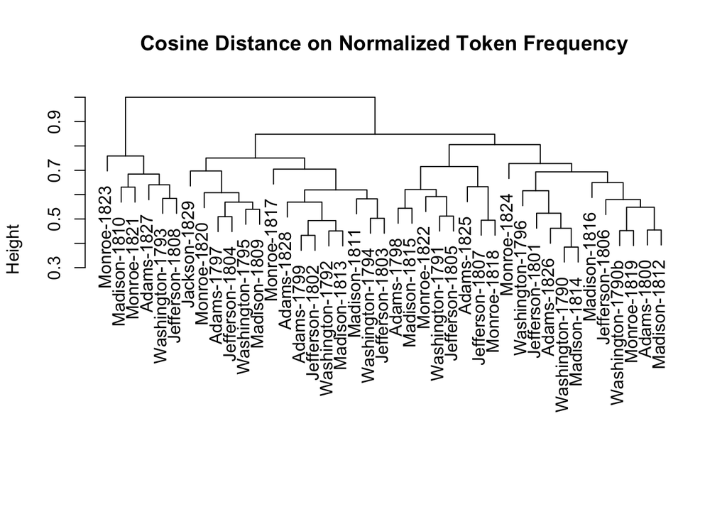

```r
pres_dfm <- tokens(corpus_subset(data_corpus_sotu,
                                 Date < "1830-01-01"), # what other columns could we filter by? Maybe party? Why?
                                  remove_punct = TRUE) %>%
  tokens_wordstem("en") %>%
  tokens_remove(stopwords("en")) %>%
  dfm() %>%
  dfm_trim(min_termfreq = 5,
           min_docfreq = 3)

# hierarchical clustering - get distances on normalized dfm
pres_dist_mat <- dfm_weight(pres_dfm,
                            scheme = "prop") %>%
    textstat_simil(method = "cosine") %>%
    as.dist()

# hiarchical clustering the distance object
pres_cluster <- hclust(pres_dist_mat)

# label with document names
pres_cluster$labels <- docnames(pres_dfm)

# plot as a dendrogram
plot(pres_cluster, xlab = "", sub = "",
     main = "Cosine Distance on Normalized Token Frequency")
```

## comparison wordclouds of Washington’s eight SOTUs

(8 is the maximum that can be plotted in a single word cloud)

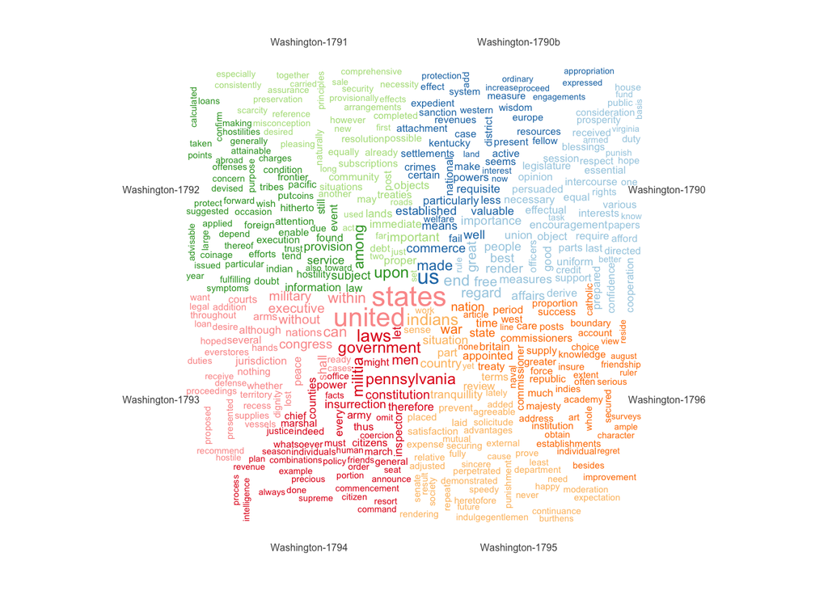

```r
dfmat_sotu_washington <- dfmat_sotu[1:8,] # [R,C] is always ROW, COLUMN because matrices are REALLY COOL
textplot_wordcloud(dfmat_sotu_washington,
                   max_size = 2, # what happens when we increase or decrease this parameter?
                   labelsize = .5,
                   comparison = TRUE,
                   labeloffset = .05)
```

## comparison wordclouds of next eight SOTUs

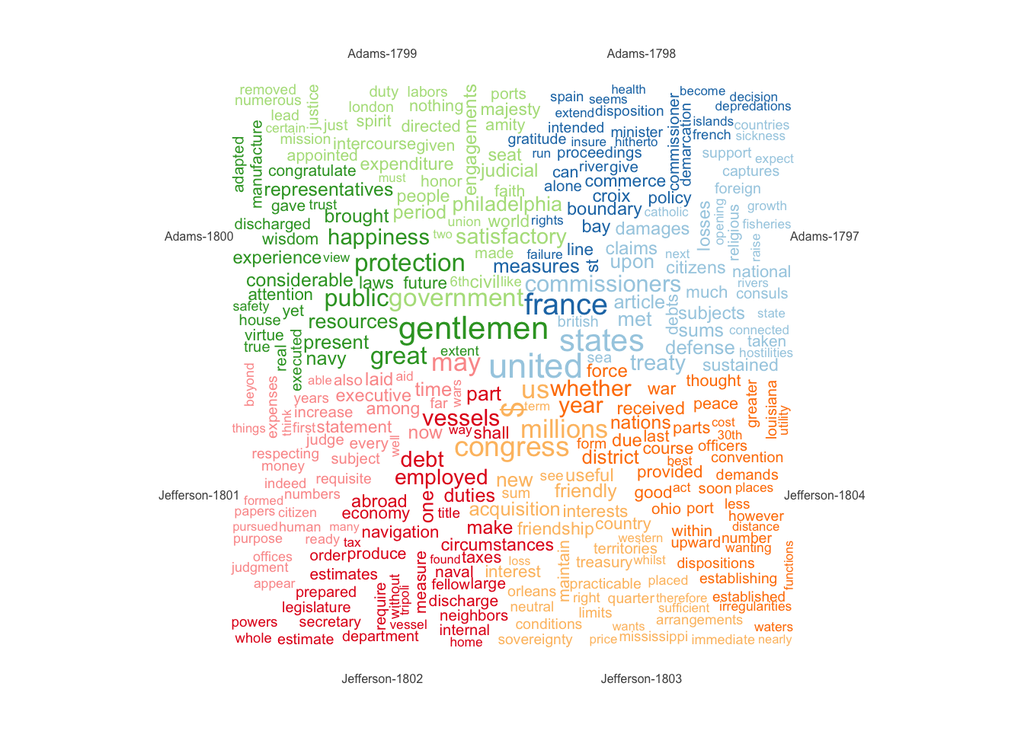

```r
dfmat_sotu_adamsjeff <- dfmat_sotu[9:16,]
textplot_wordcloud(dfmat_sotu_adamsjeff,
                   max_size = 2,
                   labelsize = .5,
                   comparison = TRUE,
                   labeloffset = .05)
```

## comparison wordclouds of Obama vs Trump SOTUs

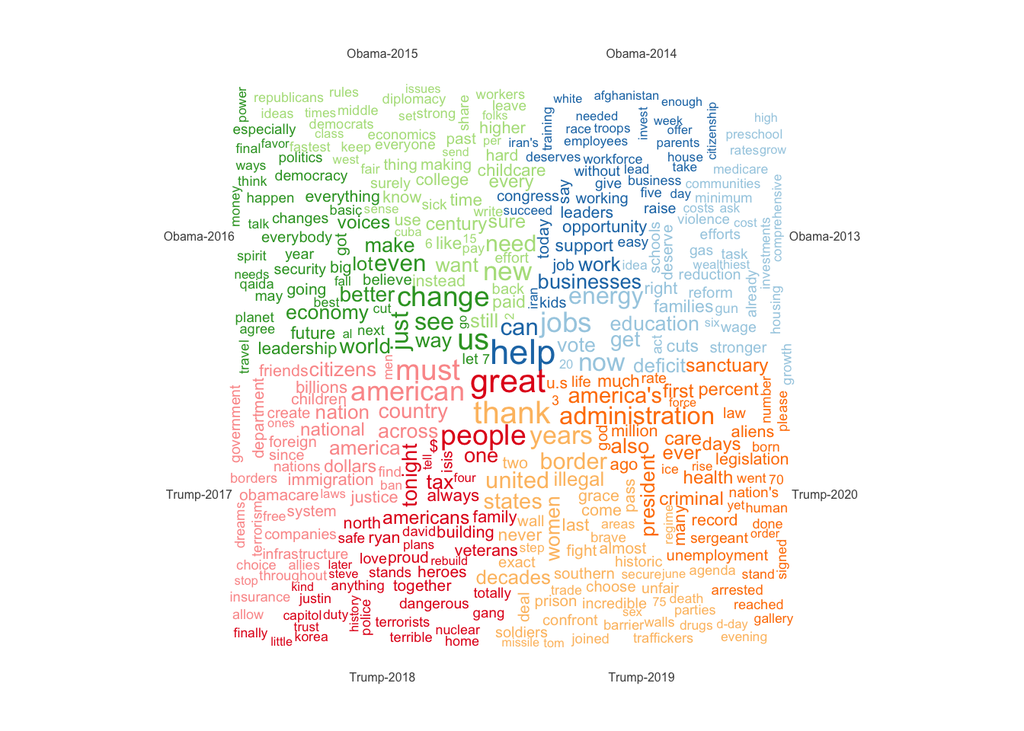

```r
dfmat_sotu_obamatrump <- dfmat_sotu[234:241,]
textplot_wordcloud(dfmat_sotu_obamatrump,
                   max_size = 2,
                   labelsize = .5,
                   comparison = TRUE,
                   labeloffset = .05)
```